# 201.12. CoaddPatches table

For the Rubin Science Platform at data.lsst.cloud.  
Data Release: [Data Preview 2](https://dp2.lsst.io/)  
Container Size: Large  
LSST Science Pipelines version: r30.0.10  
Last verified to run: 2026-07-24  
Repository: github.com/lsst/tutorial-notebooks  
DOI: 10.11578/rubin/dc.20250909.20

**Learning objective:** To understand the contents of the `CoaddPatches` table and how to access it.

**LSST data products:** `CoaddPatches`

**Packages:** `lsst.rsp.RSPDiscovery`

**Credit:** Originally developed by the Rubin Community Science team. Please consider acknowledging them if this notebook is used for the preparation of journal articles, software releases, or other notebooks.

**Get Support:** Everyone is encouraged to ask questions or raise issues in the [Support Category](https://community.lsst.org/c/support) of the Rubin Community Forum. Rubin staff will respond to all questions posted there.

## 1. Introduction

The `CoaddPatches` table contains static information about the subset of tracts and patches from the standard LSST skymap that apply to coadds in these catalog.

- TAP table name: `dp2.CoaddPatches`
- columns: 5

**Related tutorials:** The TAP data access service is demonstrated in the 100-level "How to" tutorials.

### 1.1. Import packages

Import standard python packages `numpy`, `matplotlib`, and `skyproj` for making sky projection plots.

From the `lsst` package, import `RSPDiscovery` for accessing the TAP service.

```python
import numpy as np
import matplotlib.pyplot as plt
import skyproj
from lsst.rsp import RSPDiscovery
```

### 1.2. Define parameters and functions

Instantiate `RSPDiscovery` with the DP2 release, and get the TAP service from it.

```python
discovery = RSPDiscovery("dp2")
service = discovery.get_tap_client()
```

## 2. Schema (columns)

To browse the table schema visit the [Rubin schema browser](https://sdm-schemas.lsst.io/), or use the TAP service via the Portal Aspect or as demonstrated in Section 2.1.

### 2.1. Retrieve table schema

To retrieve the table schema, define a query for the schema columns of the `CoaddPatches` table and run the query job.

```python
query = "SELECT column_name, datatype, description, unit " \
        "FROM tap_schema.columns " \
        "WHERE table_name = 'dp2.CoaddPatches'"
job = service.submit_job(query)
job.run()
job.wait(phases=['COMPLETED', 'ERROR'])
print('Job phase is', job.phase)
if job.phase == 'ERROR':
    job.raise_if_error()
```

```
Job phase is COMPLETED
```

Retrieve the query results and display them as an `astropy` table with the `to_table()` attribute.

```python
assert job.phase == 'COMPLETED'
results = job.fetch_result().to_table()
assert len(results) == 5
results
```

*Table length=5*

| column_name str64 | datatype str64 | description str512 | unit str64 |
| --- | --- | --- | --- |
| lsst_patch | long | ID number of the second level, 'patch', within the standard LSST skymap |  |
| lsst_tract | long | ID number of the top level, 'tract', within the standard LSST skymap |  |
| s_dec | double | Central Spatial Position in ICRS; Declination | deg |
| s_ra | double | Central Spatial Position in ICRS; Right ascension | deg |
| s_region | char | Sky region covered by the coadd (expressed in ICRS frame) |  |

The table displayed above has not been truncated, as it is only 5 rows long.

Delete the job, but not the `results.`

```python
del query
job.delete()
```

## 3. Data access

The `CoaddPatches` table is available via the TAP service.

**Recommended access method:** TAP.

### 3.1. TAP (Table Access Protocol)

The `CoaddPatches` table is stored in Qserv and accessible via the TAP services using ADQL queries.

#### 3.1.2. Demo query

**Avoid full-table queries.** Although the DP2 `CoaddPatches` table is relatively small, it is good practice to always include spatial constraints and only retrieve necessary columns.

Search for coadd patches within 3 degrees of the center of the Extended Chandra Deep Field South (ECDFS) field, RA, Dec = $53.13, -28.10$. Return the patch ID, tract ID, central RA, DEC, and sky region covered by the coadd.

```python
query = "SELECT lsst_patch, lsst_tract, s_ra, s_dec, s_region " \
        "FROM dp2.CoaddPatches " \
        "WHERE CONTAINS(POINT('ICRS', s_ra, s_dec), " \
        "CIRCLE('ICRS', 53.13, -28.10, 3)) = 1 "
job = service.submit_job(query)
job.run()
job.wait(phases=['COMPLETED', 'ERROR'])
print('Job phase is', job.phase)
if job.phase == 'ERROR':
    job.raise_if_error()
```

```
Job phase is COMPLETED
```

Fetch the results as an `astropy` table.

```python
assert job.phase == 'COMPLETED'
results = job.fetch_result().to_table()
print(len(results))
```

```
1246
```

Option to display the table.

```python
# results
```

Draw all patch boundaries on the sky using a McBryde sky projection, using a unique random color for each tract, and zooming in to the patch search region using `extent`.

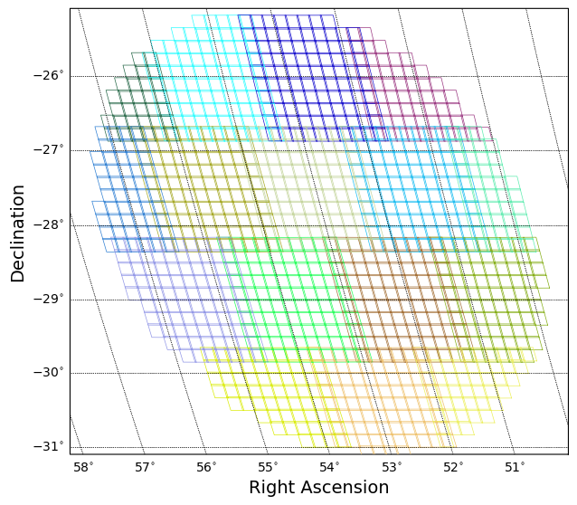

```python
tract_colors = {}
for utract in np.unique(results['lsst_tract']):
    tract_colors[utract] = np.random.rand(3)

fig, ax = plt.subplots(figsize=(6, 6))
ra_cen = 53.13
dec_cen = -28.10
radius = 3.0
extent = [ra_cen - radius, ra_cen + radius,
          dec_cen - radius, dec_cen + radius]
sp = skyproj.McBrydeSkyproj(ax=ax, extent=extent)
for i, s_region in enumerate(results['s_region']):
    vertices = np.array(s_region.split()[2:], dtype=float)
    ras = vertices[0::2]
    decs = vertices[1::2]
    sp.draw_polygon(ras, decs, edgecolor=tract_colors[results['lsst_tract'][i]],
                    alpha=1, linewidth=0.5, facecolor=None)
sp.ax.set_xlabel("Right Ascension", fontsize=14)
sp.ax.set_ylabel("Declination", fontsize=14)
plt.tight_layout()
plt.show()
del sp
```

Zoom in on the center region to better show how tracts and patches overlap.

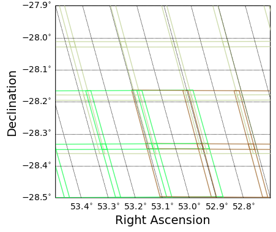

```python
fig, ax = plt.subplots(figsize=(4, 4))
ra_cen = 53.0
dec_cen = -28.2
radius = 0.3
extent = [ra_cen - radius, ra_cen + radius,
          dec_cen - radius, dec_cen + radius]
sp = skyproj.McBrydeSkyproj(ax=ax, extent=extent)
for i, s_region in enumerate(results['s_region']):
    vertices = np.array(s_region.split()[2:], dtype=float)
    ras = vertices[0::2]
    decs = vertices[1::2]
    sp.draw_polygon(ras, decs, edgecolor=tract_colors[results['lsst_tract'][i]],
                    alpha=0.8, linewidth=1, facecolor=None)
sp.ax.set_xlabel("Right Ascension", fontsize=14)
sp.ax.set_ylabel("Declination", fontsize=14)
plt.tight_layout()
plt.show()
del sp
```

> **Figure 2:** A zoom-in on the central region of Figure 1 to show how tracts overlap tracts, and patches overlap patches.

Clean up.

```python
job.delete()
del query, results
```